# Segmentation_models

```python
pip install segmentation-models
```

```
     |████████████████████████████████| 50 kB 4.4 MB/s
```

```python
import pandas as pd
import numpy as np
from matplotlib import pyplot as plt
import os
import pickle
import matplotlib.patches as patches
import re
import random
from sklearn.model_selection import train_test_split
import cv2
import seaborn as sns
import warnings
warnings.filterwarnings("ignore")
from keras.preprocessing.image import ImageDataGenerator
from tensorflow.keras.utils import plot_model
from PIL import Image
import tensorflow as tf
import keras
from keras import backend as K
from keras.models import Model,load_model
from keras.regularizers import l2
import datetime
%load_ext tensorboard
import segmentation_models
from segmentation_models import Unet
from segmentation_models import get_preprocessing
import imgaug.augmenters as iaa
import segmentation_models as sm
sm.set_framework('tf.keras')
sm.framework()
from tensorflow.keras.losses import binary_crossentropy
```

```
Segmentation Models: using `keras` framework.
```

```python
from google.colab import drive
drive.mount('/content/drive')
```

```python
with open('/content/drive//My Drive/Steel_Detection /data.pkl','rb') as f:
     train=pickle.load(f)
```

```python
train.head()
```

|  | image_id | rle_1 | rle_2 | rle_3 | rle_4 | defect | stratify | defect_1 | defect_2 | defect_3 | defect_4 | total_defects |
| --- | --- | --- | --- | --- | --- | --- | --- | --- | --- | --- | --- | --- |
| 0 | 0002cc93b.jpg | 29102 12 29346 24 29602 24 29858 24 30114 24 3... |  |  |  | 1 | 1 | 1 | 0 | 0 | 0 | 1 |
| 1 | 00031f466.jpg |  |  |  |  | 0 | 0 | 0 | 0 | 0 | 0 | 0 |
| 2 | 000418bfc.jpg |  |  |  |  | 0 | 0 | 0 | 0 | 0 | 0 | 0 |
| 3 | 000789191.jpg |  |  |  |  | 0 | 0 | 0 | 0 | 0 | 0 | 0 |
| 4 | 0007a71bf.jpg |  |  | 18661 28 18863 82 19091 110 19347 110 19603 11... |  | 1 | 3 | 0 | 0 | 1 | 0 | 1 |

```python
train.shape
```

```
(12568, 12)
```

```python
#https://scikit-learn.org/stable/modules/generated/sklearn.model_selection.train_test_split.html
x_train,x_test=train_test_split(train,test_size=0.10,stratify=train['stratify'],random_state=0)
x_train,x_val=train_test_split(x_train,test_size=0.20,stratify=x_train['stratify'],random_state=0)
print("x_train {}".format(x_train.shape),"  x_val {}".format(x_val.shape)," x_test {}".format(x_test.shape))
print("="*100)

train_1=x_train[x_train['defect_1']==1][['image_id','rle_1']].rename(columns={'image_id':'image_id','rle_1':'rle'})
train_2=x_train[x_train['defect_2']==1][['image_id','rle_2']].rename(columns={'image_id':'image_id','rle_2':'rle'})
train_3=x_train[x_train['defect_3']==1][['image_id','rle_3']].rename(columns={'image_id':'image_id','rle_3':'rle'})
train_4=x_train[x_train['defect_4']==1][['image_id','rle_4']].rename(columns={'image_id':'image_id','rle_4':'rle'})
print("train_1 {}".format(train_1.shape)," train_2 {}".format(train_2.shape)," train_3 {}".format(train_3.shape)," train_4 {}".format(train_4.shape))
print("="*100)

val_1=x_val[x_val['defect_1']==1][['image_id','rle_1']].rename(columns={'image_id':'image_id','rle_1':'rle'})
val_2=x_val[x_val['defect_2']==1][['image_id','rle_2']].rename(columns={'image_id':'image_id','rle_2':'rle'})
val_3=x_val[x_val['defect_3']==1][['image_id','rle_3']].rename(columns={'image_id':'image_id','rle_3':'rle'})
val_4=x_val[x_val['defect_4']==1][['image_id','rle_4']].rename(columns={'image_id':'image_id','rle_4':'rle'})
print("val_1 {}".format(val_1.shape)," val_2 {}".format(val_2.shape)," val_3 {}".format(val_3.shape)," val_4 {}".format(val_4.shape))
print("="*100)

test_1=x_test[x_test['defect_1']==1][['image_id','rle_1']].rename(columns={'image_id':'image_id','rle_1':'rle'})
test_2=x_test[x_test['defect_2']==1][['image_id','rle_2']].rename(columns={'image_id':'image_id','rle_2':'rle'})
test_3=x_test[x_test['defect_3']==1][['image_id','rle_3']].rename(columns={'image_id':'image_id','rle_3':'rle'})
test_4=x_test[x_test['defect_4']==1][['image_id','rle_4']].rename(columns={'image_id':'image_id','rle_4':'rle'})
print("test_1 {}".format(test_1.shape)," test_2 {}".format(test_2.shape)," test_3 {}".format(test_3.shape)," test_4 {}".format(test_4.shape))
```

```
x_train (9048, 12)   x_val (2263, 12)  x_test (1257, 12)
====================================================================================================
train_1 (646, 2)  train_2 (174, 2)  train_3 (3714, 2)  train_4 (581, 2)
====================================================================================================
val_1 (161, 2)  val_2 (50, 2)  val_3 (924, 2)  val_4 (142, 2)
====================================================================================================
test_1 (90, 2)  test_2 (23, 2)  test_3 (512, 2)  test_4 (78, 2)
```

- Data is divided with respect to 4 defects because different segmentation model is trained for each 4 defects .

```python
#https://stackoverflow.com/questions/31273652/how-to-calculate-dice-coefficient-for-measuring-accuracy-of-image-segmentation-i
def dice_coef(y_true,y_pred):
    y_true_f=tf.reshape(tf.dtypes.cast(y_true, tf.float32),[-1])
    y_pred_f=tf.reshape(tf.dtypes.cast(y_pred, tf.float32),[-1])
    intersection=tf.reduce_sum(y_true_f*y_pred_f)
    return (2. * intersection + 1.) / (tf.reduce_sum(y_true_f) + tf.reduce_sum(y_pred_f) + 1.)

#https://stackoverflow.com/questions/49785133/keras-dice-coefficient-loss-function-is-negative-and-increasing-with-epochs
def dice_loss(y_true, y_pred):
    y_true_f = tf.reshape(y_true, [-1])
    y_pred_f = tf.reshape(y_pred, [-1])
    return (1-dice_coefficient(y_true, y_pred))

#defining function for calculation of loss function: binary cross entropy + dice loss
def bce_dice_loss(y_true, y_pred):
    y_true_f = tf.reshape(y_true, [-1])
    y_pred_f = tf.reshape(y_pred, [-1])
    return binary_crossentropy(y_true, y_pred) + (1-dice_coef(y_true, y_pred))
```

```python
#https://www.kaggle.com/paulorzp/rle-functions-run-lenght-encode-decode
def rle_to_mask(rle):
    # CONVERT RLE TO MASK
    if (pd.isnull(rle))|(rle=='')|(rle=='-1'):
        return np.zeros((256,800),dtype=np.uint8)  #If the EncodedPixels string is empty an empty mask is returned

    height=256
    width=1600
    mask=np.zeros(width*height,dtype=np.uint8)

    array=np.asarray([int(x) for x in rle.split()])
    starts=array[0::2]-1
    lengths=array[1::2]
    for index,start in enumerate(starts):
        mask[int(start):int(start+lengths[index])]=1

    return mask.reshape((height,width),order='F')[::,::2]
```

- The imgaug library provides a very useful feature called Augmentation pipeline. Such a pipeline is a sequence of steps that can be applied in a fixed or random order. This also gives the flexibility to apply certain transformations to a few images and other transformations to other images.
- https://www.kaggle.com/parulpandey/overview-of-popular-image-augmentation-packages

```python
"""
Implementing custom data generator
#https://towardsdatascience.com/implementing-custom-data-generators-in-keras-de56f013581c
#https://www.kaggle.com/cdeotte/keras-unet-with-eda
"""
class train_DataGenerator(keras.utils.all_utils.Sequence):

  def __init__(self,dataframe,batch_size=4,shuffle=True,preprocess=None,info={}):
    self.batch_size = batch_size
    self.df = dataframe
    self.indices = self.df.index.tolist()
    self.preprocess = preprocess
    self.shuffle = shuffle
    self.on_epoch_end()

  def __len__(self):
    return len(self.indices) // (self.batch_size)

  def __getitem__(self, index):
    index = self.index[index * self.batch_size:(index + 1) * self.batch_size]
    batch = [self.indices[k] for k in index]

    X, y = self.__get_data(batch)
    return X, y

  def on_epoch_end(self):
    self.index = np.arange(len(self.indices))
    if self.shuffle == True:
      np.random.shuffle(self.index)

  def __get_data(self, batch):
    train_datagen = ImageDataGenerator()
    #https://www.geeksforgeeks.org/python-select-random-value-from-a-list/

    X=np.empty((self.batch_size,256,800,3),dtype=np.float32) # image place-holders
    Y=np.empty((self.batch_size,256,800,1),dtype=np.int8)# 1 mask place-holders

    for i,id in enumerate(batch):
      X[i,] = Image.open('/content/drive//My Drive/Steel_Detection /train_images/' + str(self.df['image_id'].loc[id])).resize((800,256))
      Y[i,:,:,0]=rle_to_mask(self.df['rle'].loc[id])

    t=random.choice([0,0,20,30,40])
    z=random.choice([0.9,1])
    flip=random.choice(['True','False'])
    """
    https://theailearner.com/2019/07/06/imagedatagenerator-apply_transform-method/
    https://www.tensorflow.org/api_docs/python/tf/keras/preprocessing/image/ImageDataGenerator
    tx and ty: These are the shifts in the vertical and the horizontal directions respectively.
    For instance,tx=20 will shift the image vertically by 20 pixels
    zx and zy: This zooms the image in the vertical and horizontal directions respectively.
    If less than 1, the image is zoomed in otherwise zoomed out."""

    param={'flip_horizontal':flip,'flip_vertical':flip,'tx':t,'ty':t,'zx':z,'zy':z,}
    for i,e in enumerate(X):
      X[i] = train_datagen.apply_transform(e,transform_parameters=param)
    for i,f in enumerate(Y):
      Y[i] = train_datagen.apply_transform(f,transform_parameters=param)

    # preprocess input
    if self.preprocess!=None: X = self.preprocess(X)

    return X,Y
```

```python
# Implementing custom data generator
#https://towardsdatascience.com/implementing-custom-data-generators-in-keras-de56f013581c
class test_DataGenerator(keras.utils.all_utils.Sequence):

  def __init__(self,dataframe,batch_size=1,shuffle=False,preprocess=None,info={}):
    self.batch_size = batch_size
    self.df = dataframe
    self.indices = self.df.index.tolist()
    self.preprocess = preprocess
    self.shuffle = shuffle
    self.on_epoch_end()

  def __len__(self):
    return len(self.indices) // (self.batch_size)

  def __getitem__(self, index):
    index = self.index[index * self.batch_size:(index + 1) * self.batch_size]
    batch = [self.indices[k] for k in index]

    X, y = self.__get_data(batch)
    return X, y

  def on_epoch_end(self):
    self.index = np.arange(len(self.indices))
    if self.shuffle == True:
      np.random.shuffle(self.index)

  def __get_data(self, batch):
    X = np.empty((self.batch_size,256,800,3),dtype=np.float32) # image place-holders
    Y = np.empty((self.batch_size,256,800,1),dtype=np.int8)# 1 mask place-holders

    for i, id in enumerate(batch):
      X[i,] = Image.open('/content/drive//My Drive/Steel_Detection /train_images/' + str(self.df['image_id'].loc[id])).resize((800,256))
      Y[i,:,:,0]=rle_to_mask(self.df['rle'].loc[id])

      # preprocess input
    if self.preprocess!=None: X = self.preprocess(X)

    return X,Y
```

- Load UNET with pre-training on Imagenet data with backbone model as efficientnetb5.

```python
#https://segmentation-models.readthedocs.io/en/latest/tutorial.html
#LOAD UNET WITH PRETRAINING FROM IMAGENET
#https://segmentation-models.readthedocs.io/en/latest/tutorial.html
preprocess=get_preprocessing('efficientnetb5')
model=Unet('efficientnetb5',classes=1,activation='sigmoid',encoder_weights='imagenet')
model._name="Segmentation_Model"
model.summary()
```

[output not shown]

[output cut: 1249 more lines]

```
__________________________________________________________________________________________________
decoder_stage4b_conv (Conv2D)   (None, None, None, 1 2304        decoder_stage4a_relu[0][0]
__________________________________________________________________________________________________
decoder_stage4b_bn (BatchNormal (None, None, None, 1 64          decoder_stage4b_conv[0][0]
__________________________________________________________________________________________________
decoder_stage4b_relu (Activatio (None, None, None, 1 0           decoder_stage4b_bn[0][0]
__________________________________________________________________________________________________
final_conv (Conv2D)             (None, None, None, 1 145         decoder_stage4b_relu[0][0]
__________________________________________________________________________________________________
sigmoid (Activation)            (None, None, None, 1 0           final_conv[0][0]
==================================================================================================
Total params: 37,468,673
Trainable params: 37,293,953
Non-trainable params: 174,720
__________________________________________________________________________________________________
```

# Defect_1

```python
train_batch=train_DataGenerator(train_1,shuffle=True,preprocess=preprocess)
valid_batch=test_DataGenerator(val_1,preprocess=preprocess)

log_dir=os.path.join("logs",datetime.datetime.now().strftime("%Y%m%d-%H%M%S"))
tensorboard=tf.keras.callbacks.TensorBoard(log_dir=log_dir,histogram_freq=1,write_graph=True,write_grads=True)

checkpoint_filepath='/content/drive//My Drive/Steel_Detection /segmentation_defect_1.h5'
model_checkpoint_callback=tf.keras.callbacks.ModelCheckpoint(filepath=checkpoint_filepath,monitor='val_dice_coef',mode='max',save_best_only=True)
#https://keras.io/api/metrics/
#https://keras.io/api/losses/probabilistic_losses/#categorical_crossentropy-function
model.compile(optimizer='adam',loss=bce_dice_loss,metrics=[dice_coef])
callback=[model_checkpoint_callback,tensorboard]
#https://datascience.stackexchange.com/questions/34444/what-is-the-difference-between-fit-and-fit-generator-in-keras
history=model.fit_generator(train_batch,validation_data=valid_batch,epochs=25,verbose=1,callbacks=callback)
```

```
WARNING:tensorflow:`write_grads` will be ignored in TensorFlow 2.0 for the `TensorBoard` Callback.
```

```python
%tensorboard --logdir logs
```

```python
print('Training Dataset:\n')
print(model.evaluate(test_DataGenerator(train_1,preprocess=preprocess),verbose=1))
print("="*100)
print('\nValidation Dataset:\n')
print(model.evaluate(test_DataGenerator(val_1,preprocess=preprocess),verbose=1))
print("="*100)
print('\nTest Dataset:\n')
print(model.evaluate(test_DataGenerator(test_1,preprocess=preprocess),verbose=1))
```

```
Training Dataset:

[0.44973498582839966, 0.6004406809806824]
====================================================================================================

Validation Dataset:

[0.48095887899398804, 0.5743771195411682]
====================================================================================================

Test Dataset:

[0.4948919415473938, 0.563205361366272]
```

- For validation,test datasets loss increases and metrics decreases as compared with train data thus better to train model for more epochs (e.g. epoch =100) which might help to reduce loss and increase dice coefficient on unseen data.

```python
def rle2mask(rle):
    # CONVERT RLE TO MASK
    if (pd.isnull(rle))|(rle=='')|(rle=='-1'):
        return np.zeros((256,1600) ,dtype=np.uint8)

    height= 256
    width = 1600
    mask= np.zeros( width*height ,dtype=np.uint8)

    array = np.asarray([int(x) for x in rle.split()])
    starts = array[0::2]-1
    lengths = array[1::2]
    for index, start in enumerate(starts):
        mask[int(start):int(start+lengths[index])] = 1

    return mask.reshape( (height,width), order='F' )
```

```python
model=load_model('/content/drive//My Drive/Steel_Detection /segmentation_defect_1.h5',custom_objects={'bce_dice_loss':bce_dice_loss,'dice_coef':dice_coef})
```

```python
def plot_mask(rle_defect,k,pred):
  train_folder_path='/content/drive//My Drive/Steel_Detection /train_images/'
  # Create figure and axes
  fig,ax=plt.subplots(4,3,figsize=(14,9))
  fig.suptitle('Defect_'+str(k)+'_Images',fontsize=20,fontweight='bold')
  for i in range(4):
    image_id=rle_defect[i][0]
    rle=rle_defect[i][1]
    im=Image.open(train_folder_path+str(image_id))
    ax[i,0].imshow(im)
    ax[i,0].set_title(image_id)
    mask=rle2mask(rle)
    ax[i,1].imshow(mask)
    ax[i,1].set_title("Actual Mask for "+str(image_id))
    c1=Image.fromarray(pred[i][:,:,0])
    ax[i,2].imshow(np.array(c1.resize((1600,256)))>0.5)
    ax[i,2].set_title("Predicted Mask for "+str(image_id))
  fig.set_facecolor("tan")
  plt.show()
```

# Train Dataset

```python
train_preds=model.predict_generator(test_DataGenerator(train_1[10:14],preprocess=preprocess),verbose=1)
```

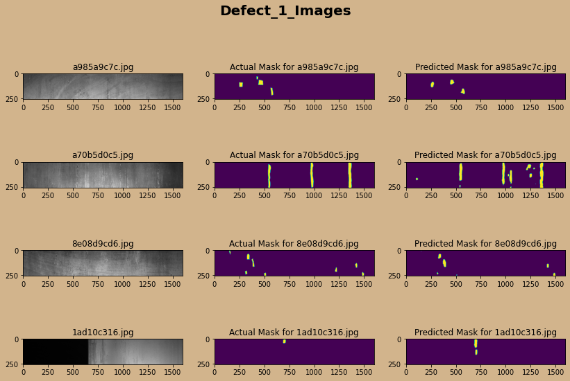

```python
plot_mask(train_1[10:14].values,1,train_preds)
```

# Validation Dataset

```python
val_preds=model.predict_generator(test_DataGenerator(val_1[10:14],preprocess=preprocess),verbose=1)
```

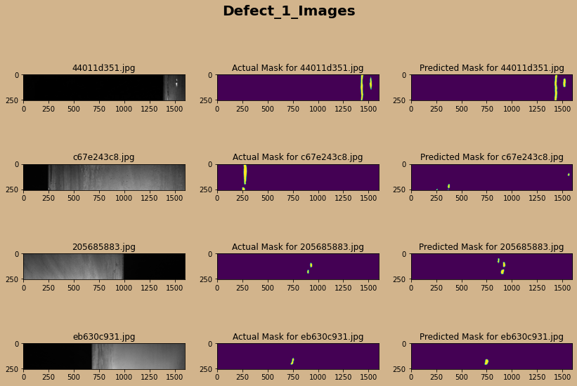

```python
plot_mask(val_1[10:14].values,1,val_preds)
```

# Test Dataset

```python
test_preds=model.predict_generator(test_DataGenerator(test_1[10:14],preprocess=preprocess),verbose=1)
```

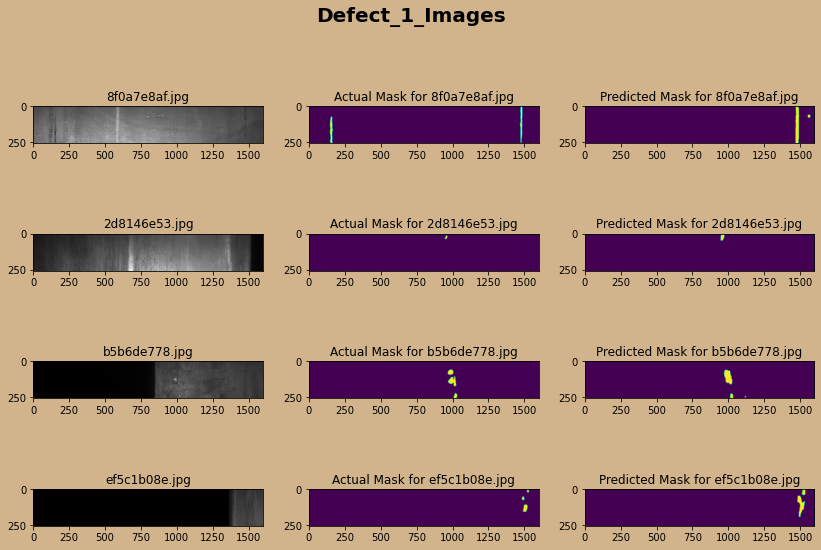

```python
plot_mask(test_1[10:14].values,1,test_preds)
```

# Defect_2

```python
train_batch=train_DataGenerator(train_2,shuffle=True,preprocess=preprocess)
valid_batch=test_DataGenerator(val_2,preprocess=preprocess)

log_dir=os.path.join("logs",datetime.datetime.now().strftime("%Y%m%d-%H%M%S"))
tensorboard=tf.keras.callbacks.TensorBoard(log_dir=log_dir,histogram_freq=1,write_graph=True,write_grads=True)

checkpoint_filepath='/content/drive//My Drive/Steel_Detection /segmentation_defect_2.h5'
model_checkpoint_callback=tf.keras.callbacks.ModelCheckpoint(filepath=checkpoint_filepath,monitor='val_dice_coef',mode='max',save_best_only=True)
#https://keras.io/api/metrics/
#https://keras.io/api/losses/probabilistic_losses/#categorical_crossentropy-function
model.compile(optimizer='adam',loss=bce_dice_loss,metrics=[dice_coef])
callback=[model_checkpoint_callback,tensorboard]
#https://datascience.stackexchange.com/questions/34444/what-is-the-difference-between-fit-and-fit-generator-in-keras
history=model.fit_generator(train_batch,validation_data=valid_batch,epochs=25,verbose=1,callbacks=callback)
```

```
WARNING:tensorflow:`write_grads` will be ignored in TensorFlow 2.0 for the `TensorBoard` Callback.
```

```python
%tensorboard --logdir logs
```

```python
model=load_model('/content/drive//My Drive/Steel_Detection /segmentation_defect_2.h5',custom_objects={'bce_dice_loss':bce_dice_loss,'dice_coef':dice_coef})
```

```python
print('Training Dataset:\n')
print(model.evaluate(test_DataGenerator(train_2,preprocess=preprocess),verbose=1))
print("="*100)
print('\nValidation Dataset:\n')
print(model.evaluate(test_DataGenerator(val_2,preprocess=preprocess),verbose=1))
print("="*100)
print('\nTest Dataset:\n')
print(model.evaluate(test_DataGenerator(test_2,preprocess=preprocess),verbose=1))
```

```
Training Dataset:

[0.451008677482605, 0.5829356908798218]
====================================================================================================

Validation Dataset:

[0.4260036051273346, 0.6026241779327393]
====================================================================================================

Test Dataset:

[0.394377201795578, 0.6390075087547302]
```

- One can observe the value of loss and metrics are similar for train,validation and test datasets thus the model is not over-fitting. On unseen data (test) dice coefficient increases and loss decreases as compared to train, validation datasets thus, model is performing really good.

# Training Dataset

```python
train_preds=model.predict_generator(test_DataGenerator(train_2[10:14],preprocess=preprocess),verbose=1)
```

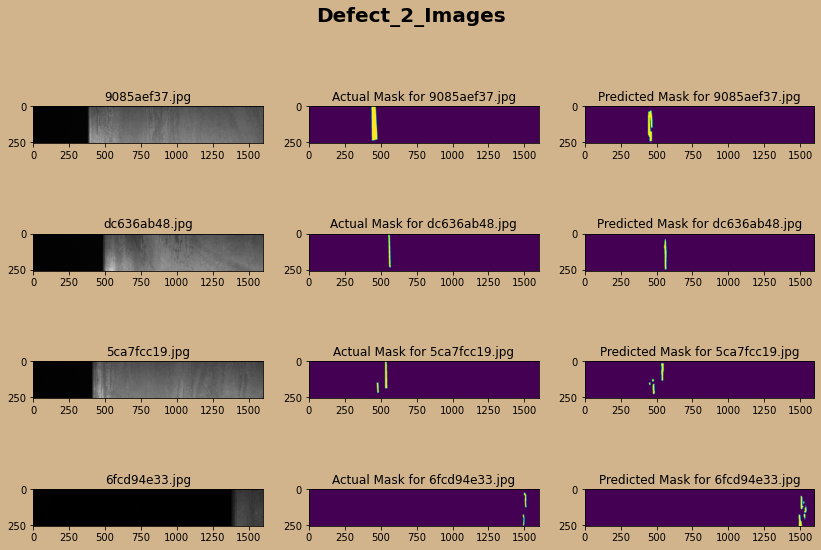

```python
plot_mask(train_2[10:14].values,2,train_preds)
```

# Validation Dataset

```python
val_preds=model.predict_generator(test_DataGenerator(val_2[10:14],preprocess=preprocess),verbose=1)
```

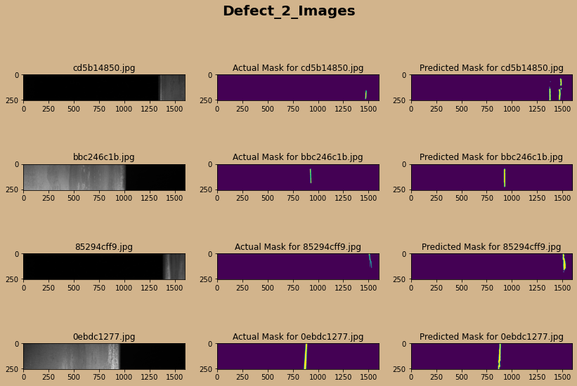

```python
plot_mask(val_2[10:14].values,2,val_preds)
```

# Test Datset

```python
test_preds=model.predict_generator(test_DataGenerator(test_2[10:14],preprocess=preprocess),verbose=1)
```

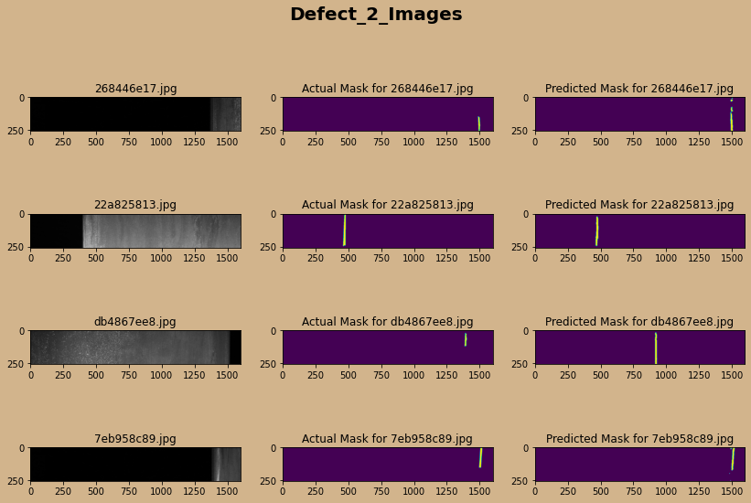

```python
plot_mask(test_2[10:14].values,2,test_preds)
```

# Defect 3

```python
train_batch=train_DataGenerator(train_3,shuffle=True,preprocess=preprocess)
valid_batch=test_DataGenerator(val_3,preprocess=preprocess)

log_dir=os.path.join("logs",datetime.datetime.now().strftime("%Y%m%d-%H%M%S"))
tensorboard=tf.keras.callbacks.TensorBoard(log_dir=log_dir,histogram_freq=1,write_graph=True,write_grads=True)

checkpoint_filepath='/content/drive//My Drive/Steel_Detection /segmentation_defect_3.h5'
model_checkpoint_callback=tf.keras.callbacks.ModelCheckpoint(filepath=checkpoint_filepath,monitor='val_dice_coef',mode='max',save_best_only=True)
#https://keras.io/api/metrics/
#https://keras.io/api/losses/probabilistic_losses/#categorical_crossentropy-function
model.compile(optimizer='adam',loss=bce_dice_loss,metrics=[dice_coef])
callback=[model_checkpoint_callback,tensorboard]
#https://datascience.stackexchange.com/questions/34444/what-is-the-difference-between-fit-and-fit-generator-in-keras
history=model.fit_generator(train_batch,validation_data=valid_batch,epochs=6,verbose=1,callbacks=callback)
```

```
WARNING:tensorflow:`write_grads` will be ignored in TensorFlow 2.0 for the `TensorBoard` Callback.
```

```python
%tensorboard --logdir logs
```

```python
model=load_model('/content/drive//My Drive/Steel_Detection /segmentation_defect_3.h5',custom_objects={'bce_dice_loss':bce_dice_loss,'dice_coef':dice_coef})
```

```python
print('Training Dataset:\n')
print(model.evaluate(test_DataGenerator(train_3,preprocess=preprocess),verbose=1))
print("="*100)
print('\nValidation Dataset:\n')
print(model.evaluate(test_DataGenerator(val_3,preprocess=preprocess),verbose=1))
print("="*100)
print('\nTest Dataset:\n')
print(model.evaluate(test_DataGenerator(test_3,preprocess=preprocess),verbose=1))
```

```
Training Dataset:

[0.4716576039791107, 0.6474675536155701]
====================================================================================================

Validation Dataset:

[0.48533451557159424, 0.6430497765541077]
====================================================================================================

Test Dataset:

[0.47314369678497314, 0.6479683518409729]
```

# Training Dataset

```python
train_preds=model.predict_generator(test_DataGenerator(train_3[12:16],preprocess=preprocess),verbose=1)
```

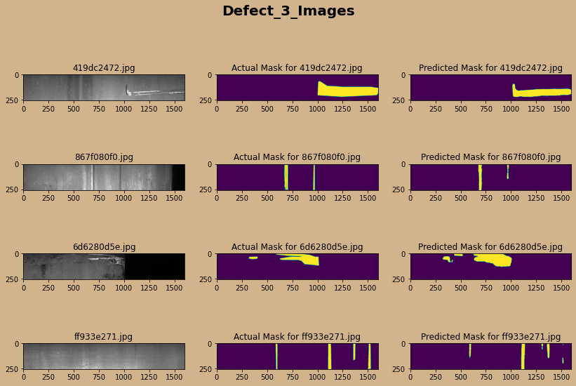

```python
plot_mask(train_3[12:16].values,3,train_preds)
```

# Validation Dataset

```python
val_preds=model.predict_generator(test_DataGenerator(val_3[12:16],preprocess=preprocess),verbose=1)
```

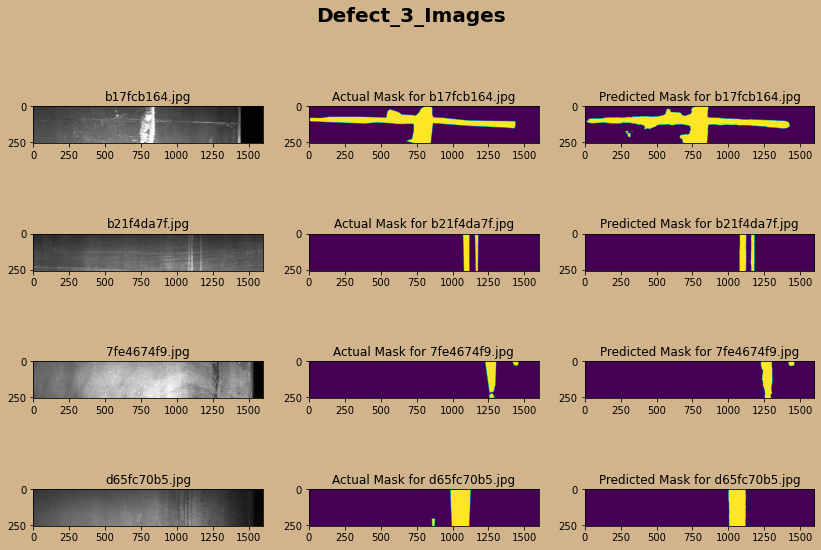

```python
plot_mask(val_3[12:16].values,3,val_preds)
```

# Test Dataset

```python
test_preds=model.predict_generator(test_DataGenerator(test_3[12:16],preprocess=preprocess),verbose=1)
```

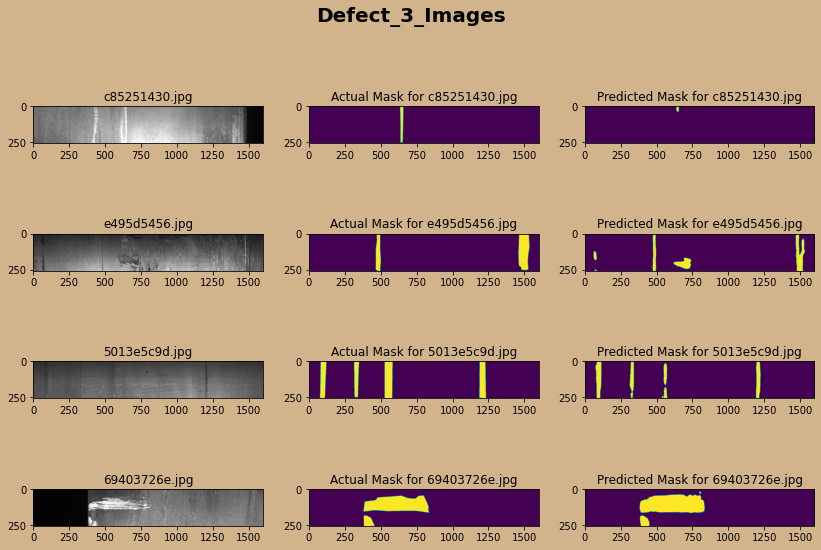

```python
plot_mask(test_3[12:16].values,3,test_preds)
```

# Defect 4

```python
train_batch=train_DataGenerator(train_4,shuffle=True,preprocess=preprocess)
valid_batch=test_DataGenerator(val_4,preprocess=preprocess)

log_dir=os.path.join("logs",datetime.datetime.now().strftime("%Y%m%d-%H%M%S"))
tensorboard=tf.keras.callbacks.TensorBoard(log_dir=log_dir,histogram_freq=1,write_graph=True,write_grads=True)

checkpoint_filepath='/content/drive//My Drive/Steel_Detection /segmentation_defect_4.h5'
model_checkpoint_callback=tf.keras.callbacks.ModelCheckpoint(filepath=checkpoint_filepath,monitor='val_dice_coef',mode='max',save_best_only=True)
#https://keras.io/api/metrics/
#https://keras.io/api/losses/probabilistic_losses/#categorical_crossentropy-function
model.compile(optimizer='adam',loss=bce_dice_loss,metrics=[dice_coef])
callback=[model_checkpoint_callback,tensorboard]
#https://datascience.stackexchange.com/questions/34444/what-is-the-difference-between-fit-and-fit-generator-in-keras
history=model.fit_generator(train_batch,validation_data=valid_batch,epochs=25,verbose=1,callbacks=callback)
```

```
WARNING:tensorflow:`write_grads` will be ignored in TensorFlow 2.0 for the `TensorBoard` Callback.
```

```python
%tensorboard --logdir logs
```

```python
model=load_model('/content/drive//My Drive/Steel_Detection /segmentation_defect_4.h5',custom_objects={'bce_dice_loss':bce_dice_loss,'dice_coef':dice_coef})
```

```python
print('Training Dataset:\n')
print(model.evaluate(test_DataGenerator(train_4,preprocess=preprocess),verbose=1))
print("="*100)
print('\nValidation Dataset:\n')
print(model.evaluate(test_DataGenerator(val_4,preprocess=preprocess),verbose=1))
print("="*100)
print('\nTest Dataset:\n')
print(model.evaluate(test_DataGenerator(test_4,preprocess=preprocess),verbose=1))
```

```
Training Dataset:

[0.400820791721344, 0.7201958894729614]
====================================================================================================

Validation Dataset:

[0.40297946333885193, 0.7157671451568604]
====================================================================================================

Test Dataset:

[0.42307525873184204, 0.7077347636222839]
```

- For validation,test datasets loss slightly increases and metrics slightly decreases as compared with train data but overall values are similar thus model is not over-fitting. For better results on unseen data train model for more epochs (e.g. epoch =100) based on the available resources (memory).

# Training Dataset

```python
train_preds=model.predict_generator(test_DataGenerator(train_4[14:18],preprocess=preprocess),verbose=1)
```

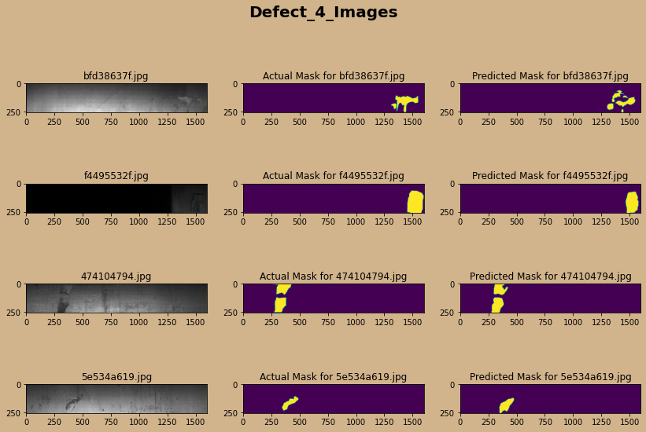

```python
plot_mask(train_4[14:18].values,4,train_preds)
```

# Validation Dataset

```python
val_preds=model.predict_generator(test_DataGenerator(val_4[14:18],preprocess=preprocess),verbose=1)
```

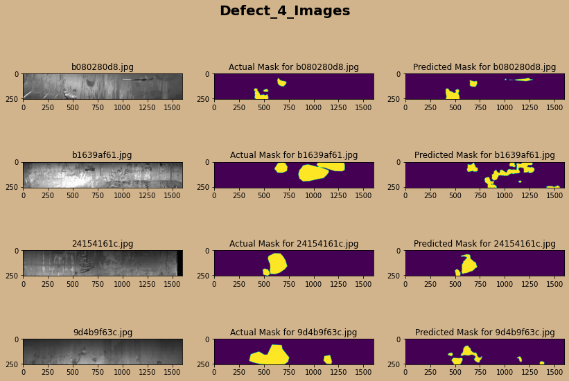

```python
plot_mask(val_4[14:18].values,4,val_preds)
```

# Test Dataset

```python
test_preds=model.predict_generator(test_DataGenerator(test_4[14:18],preprocess=preprocess),verbose=1)
```

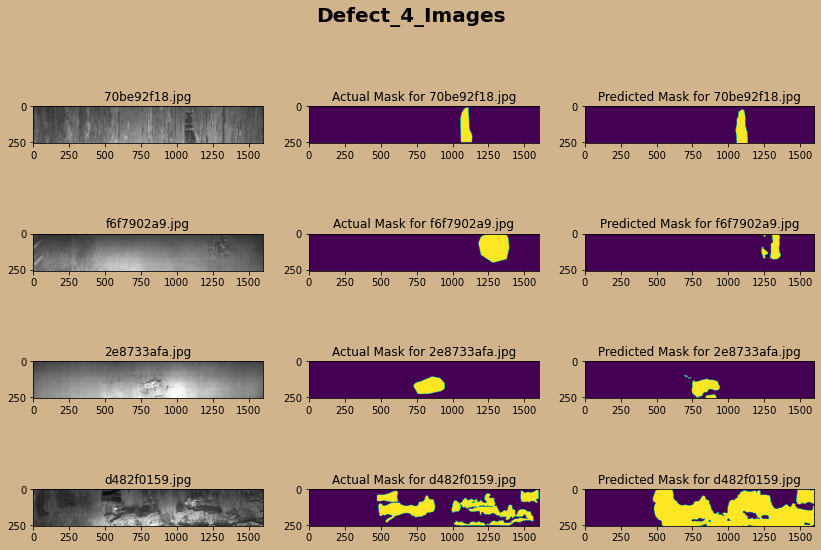

```python
plot_mask(test_4[14:18].values,4,test_preds)
```